# Risk Factor Analysis

## Outcome Variable

**Outcome Variable:** wasted

## Predictor Variables

**Intervention Variable:** fhtcm

**Adjustment Set:**

- arm
- W_mage
- W_fage
- meducyrs
- feducyrs
- W_mhtcm
- W_mwtkg
- W_mbmi
- single
- delta_W_mage
- delta_W_fage
- delta_meducyrs
- delta_feducyrs
- delta_W_mhtcm
- delta_W_mwtkg
- delta_W_mbmi
- delta_single

## Stratifying Variables

The analysis was stratified on these variable(s):

- agecat
- studyid
- country

## Data Summary

| agecat | studyid | country | fhtcm | wasted | n_cell | n |
| --- | --- | --- | --- | --- | --- | --- |
| Birth | COHORTS | GUATEMALA | >=167 cm | 0 | 22 | 192 |
| Birth | COHORTS | GUATEMALA | >=167 cm | 1 | 4 | 192 |
| Birth | COHORTS | GUATEMALA | <162 cm | 0 | 92 | 192 |
| Birth | COHORTS | GUATEMALA | <162 cm | 1 | 20 | 192 |
| Birth | COHORTS | GUATEMALA | [162-167) cm | 0 | 42 | 192 |
| Birth | COHORTS | GUATEMALA | [162-167) cm | 1 | 12 | 192 |
| Birth | Keneba | GAMBIA | >=167 cm | 0 | 550 | 1114 |
| Birth | Keneba | GAMBIA | >=167 cm | 1 | 183 | 1114 |
| Birth | Keneba | GAMBIA | <162 cm | 0 | 58 | 1114 |
| Birth | Keneba | GAMBIA | <162 cm | 1 | 25 | 1114 |
| Birth | Keneba | GAMBIA | [162-167) cm | 0 | 228 | 1114 |
| Birth | Keneba | GAMBIA | [162-167) cm | 1 | 70 | 1114 |
| Birth | PROBIT | BELARUS | >=167 cm | 0 | 9244 | 12461 |
| Birth | PROBIT | BELARUS | >=167 cm | 1 | 2428 | 12461 |
| Birth | PROBIT | BELARUS | <162 cm | 0 | 128 | 12461 |
| Birth | PROBIT | BELARUS | <162 cm | 1 | 40 | 12461 |
| Birth | PROBIT | BELARUS | [162-167) cm | 0 | 482 | 12461 |
| Birth | PROBIT | BELARUS | [162-167) cm | 1 | 139 | 12461 |
| Birth | SAS-CompFeed | INDIA | >=167 cm | 0 | 286 | 657 |
| Birth | SAS-CompFeed | INDIA | >=167 cm | 1 | 26 | 657 |
| Birth | SAS-CompFeed | INDIA | <162 cm | 0 | 153 | 657 |
| Birth | SAS-CompFeed | INDIA | <162 cm | 1 | 6 | 657 |
| Birth | SAS-CompFeed | INDIA | [162-167) cm | 0 | 164 | 657 |
| Birth | SAS-CompFeed | INDIA | [162-167) cm | 1 | 22 | 657 |
| 6 months | COHORTS | GUATEMALA | >=167 cm | 0 | 44 | 336 |
| 6 months | COHORTS | GUATEMALA | >=167 cm | 1 | 0 | 336 |
| 6 months | COHORTS | GUATEMALA | <162 cm | 0 | 190 | 336 |
| 6 months | COHORTS | GUATEMALA | <162 cm | 1 | 8 | 336 |
| 6 months | COHORTS | GUATEMALA | [162-167) cm | 0 | 89 | 336 |
| 6 months | COHORTS | GUATEMALA | [162-167) cm | 1 | 5 | 336 |
| 6 months | Keneba | GAMBIA | >=167 cm | 0 | 923 | 1510 |
| 6 months | Keneba | GAMBIA | >=167 cm | 1 | 56 | 1510 |
| 6 months | Keneba | GAMBIA | <162 cm | 0 | 104 | 1510 |
| 6 months | Keneba | GAMBIA | <162 cm | 1 | 9 | 1510 |
| 6 months | Keneba | GAMBIA | [162-167) cm | 0 | 397 | 1510 |
| 6 months | Keneba | GAMBIA | [162-167) cm | 1 | 21 | 1510 |
| 6 months | PROBIT | BELARUS | >=167 cm | 0 | 11068 | 11891 |
| 6 months | PROBIT | BELARUS | >=167 cm | 1 | 74 | 11891 |
| 6 months | PROBIT | BELARUS | <162 cm | 0 | 155 | 11891 |
| 6 months | PROBIT | BELARUS | <162 cm | 1 | 1 | 11891 |
| 6 months | PROBIT | BELARUS | [162-167) cm | 0 | 592 | 11891 |
| 6 months | PROBIT | BELARUS | [162-167) cm | 1 | 1 | 11891 |
| 6 months | SAS-CompFeed | INDIA | >=167 cm | 0 | 332 | 807 |
| 6 months | SAS-CompFeed | INDIA | >=167 cm | 1 | 38 | 807 |
| 6 months | SAS-CompFeed | INDIA | <162 cm | 0 | 170 | 807 |
| 6 months | SAS-CompFeed | INDIA | <162 cm | 1 | 23 | 807 |
| 6 months | SAS-CompFeed | INDIA | [162-167) cm | 0 | 212 | 807 |
| 6 months | SAS-CompFeed | INDIA | [162-167) cm | 1 | 32 | 807 |
| 6 months | SAS-FoodSuppl | INDIA | >=167 cm | 0 | 88 | 371 |
| 6 months | SAS-FoodSuppl | INDIA | >=167 cm | 1 | 14 | 371 |
| 6 months | SAS-FoodSuppl | INDIA | <162 cm | 0 | 115 | 371 |
| 6 months | SAS-FoodSuppl | INDIA | <162 cm | 1 | 33 | 371 |
| 6 months | SAS-FoodSuppl | INDIA | [162-167) cm | 0 | 101 | 371 |
| 6 months | SAS-FoodSuppl | INDIA | [162-167) cm | 1 | 20 | 371 |
| 24 months | COHORTS | GUATEMALA | >=167 cm | 0 | 69 | 532 |
| 24 months | COHORTS | GUATEMALA | >=167 cm | 1 | 3 | 532 |
| 24 months | COHORTS | GUATEMALA | <162 cm | 0 | 292 | 532 |
| 24 months | COHORTS | GUATEMALA | <162 cm | 1 | 19 | 532 |
| 24 months | COHORTS | GUATEMALA | [162-167) cm | 0 | 140 | 532 |
| 24 months | COHORTS | GUATEMALA | [162-167) cm | 1 | 9 | 532 |
| 24 months | Keneba | GAMBIA | >=167 cm | 0 | 743 | 1298 |
| 24 months | Keneba | GAMBIA | >=167 cm | 1 | 80 | 1298 |
| 24 months | Keneba | GAMBIA | <162 cm | 0 | 79 | 1298 |
| 24 months | Keneba | GAMBIA | <162 cm | 1 | 17 | 1298 |
| 24 months | Keneba | GAMBIA | [162-167) cm | 0 | 344 | 1298 |
| 24 months | Keneba | GAMBIA | [162-167) cm | 1 | 35 | 1298 |
| 24 months | PROBIT | BELARUS | >=167 cm | 0 | 3361 | 3608 |
| 24 months | PROBIT | BELARUS | >=167 cm | 1 | 25 | 3608 |
| 24 months | PROBIT | BELARUS | <162 cm | 0 | 50 | 3608 |
| 24 months | PROBIT | BELARUS | <162 cm | 1 | 2 | 3608 |
| 24 months | PROBIT | BELARUS | [162-167) cm | 0 | 168 | 3608 |
| 24 months | PROBIT | BELARUS | [162-167) cm | 1 | 2 | 3608 |

The following strata were considered:

- agecat: 24 months, studyid: COHORTS, country: GUATEMALA
- agecat: 24 months, studyid: Keneba, country: GAMBIA
- agecat: 24 months, studyid: PROBIT, country: BELARUS
- agecat: 6 months, studyid: COHORTS, country: GUATEMALA
- agecat: 6 months, studyid: Keneba, country: GAMBIA
- agecat: 6 months, studyid: PROBIT, country: BELARUS
- agecat: 6 months, studyid: SAS-CompFeed, country: INDIA
- agecat: 6 months, studyid: SAS-FoodSuppl, country: INDIA
- agecat: Birth, studyid: COHORTS, country: GUATEMALA
- agecat: Birth, studyid: Keneba, country: GAMBIA
- agecat: Birth, studyid: PROBIT, country: BELARUS
- agecat: Birth, studyid: SAS-CompFeed, country: INDIA

### Dropped Strata

Some strata were dropped due to rare outcomes:

- agecat: Birth, studyid: COHORTS, country: GUATEMALA
- agecat: 6 months, studyid: COHORTS, country: GUATEMALA
- agecat: 6 months, studyid: PROBIT, country: BELARUS
- agecat: 24 months, studyid: COHORTS, country: GUATEMALA
- agecat: 24 months, studyid: PROBIT, country: BELARUS

## Methods Detail

We’re interested in the causal parameters $E[Y_a]$ for all values of $a \in \mathcal{A}$. These parameters represent the mean outcome if, possibly contrary to fact, we intervened to set all units to have $A=a$. Under the randomization and positivity assumptions, these are identified by the statistical parameters $\psi_a=E_W[E_{Y|A,W}(Y|A=a,W)]$. In addition, we’re interested in the mean of $Y$, $E[Y]$ under no intervention (the observed mean). We will estimate these parameters by using SuperLearner to fit the relevant likelihood factors – $E_{Y|A,W}(Y|A=a,W)$ and $p(A=a|W)$, and then updating our likelihood fit using a joint TMLE.

For unadjusted analyses ($W=\{\}$), initial likelihoods were estimated using Lrnr_glm to estimate the simple $E(Y|A)$ and Lrnr_mean to estimate $p(A)$. For adjusted analyses, a small library containing Lrnr_glmnet, Lrnr_xgboost, and Lrnr_mean was used.

Having estimated these parameters, we will then use the delta method to estimate relative risks and attributable risks relative to a prespecified baseline level of $A$.

# Results Detail

## Results Plots

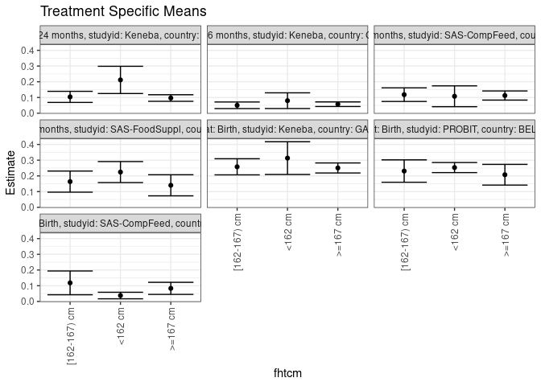

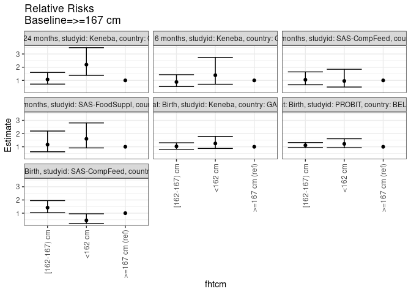

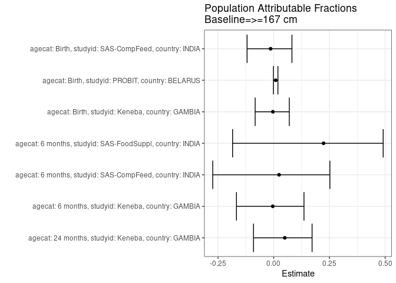

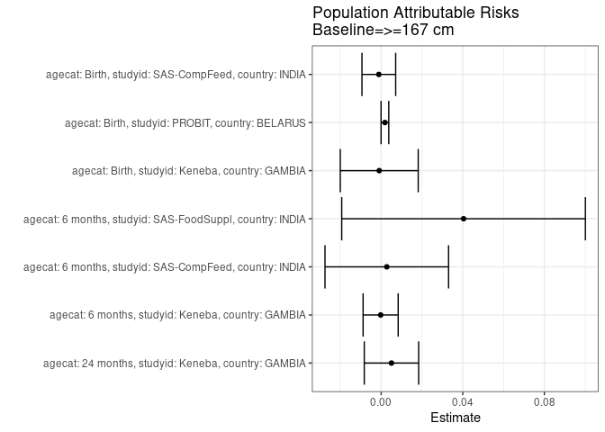

## Results Table

### Parameter: TSM

| agecat | studyid | country | intervention_level | baseline_level | estimate | ci_lower | ci_upper |
| --- | --- | --- | --- | --- | --- | --- | --- |
| Birth | Keneba | GAMBIA | >=167 cm | NA | 0.2504857 | 0.2185120 | 0.2824593 |
| Birth | Keneba | GAMBIA | <162 cm | NA | 0.3132068 | 0.2091307 | 0.4172829 |
| Birth | Keneba | GAMBIA | [162-167) cm | NA | 0.2579417 | 0.2067125 | 0.3091708 |
| Birth | PROBIT | BELARUS | >=167 cm | NA | 0.2073666 | 0.1413893 | 0.2733439 |
| Birth | PROBIT | BELARUS | <162 cm | NA | 0.2530902 | 0.2210391 | 0.2851413 |
| Birth | PROBIT | BELARUS | [162-167) cm | NA | 0.2307971 | 0.1596011 | 0.3019931 |
| Birth | SAS-CompFeed | INDIA | >=167 cm | NA | 0.0833333 | 0.0448740 | 0.1217926 |
| Birth | SAS-CompFeed | INDIA | <162 cm | NA | 0.0377358 | 0.0169272 | 0.0585445 |
| Birth | SAS-CompFeed | INDIA | [162-167) cm | NA | 0.1182796 | 0.0425886 | 0.1939705 |
| 6 months | Keneba | GAMBIA | >=167 cm | NA | 0.0572012 | 0.0426496 | 0.0717529 |
| 6 months | Keneba | GAMBIA | <162 cm | NA | 0.0796460 | 0.0297102 | 0.1295818 |
| 6 months | Keneba | GAMBIA | [162-167) cm | NA | 0.0502392 | 0.0292917 | 0.0711867 |
| 6 months | SAS-CompFeed | INDIA | >=167 cm | NA | 0.1124780 | 0.0833565 | 0.1415995 |
| 6 months | SAS-CompFeed | INDIA | <162 cm | NA | 0.1076729 | 0.0414124 | 0.1739335 |
| 6 months | SAS-CompFeed | INDIA | [162-167) cm | NA | 0.1180099 | 0.0747699 | 0.1612499 |
| 6 months | SAS-FoodSuppl | INDIA | >=167 cm | NA | 0.1401995 | 0.0730503 | 0.2073487 |
| 6 months | SAS-FoodSuppl | INDIA | <162 cm | NA | 0.2243902 | 0.1575283 | 0.2912520 |
| 6 months | SAS-FoodSuppl | INDIA | [162-167) cm | NA | 0.1636498 | 0.0963598 | 0.2309398 |
| 24 months | Keneba | GAMBIA | >=167 cm | NA | 0.0966363 | 0.0757531 | 0.1175196 |
| 24 months | Keneba | GAMBIA | <162 cm | NA | 0.2117540 | 0.1251575 | 0.2983506 |
| 24 months | Keneba | GAMBIA | [162-167) cm | NA | 0.1037661 | 0.0685031 | 0.1390291 |

### Parameter: E(Y)

| agecat | studyid | country | intervention_level | baseline_level | estimate | ci_lower | ci_upper |
| --- | --- | --- | --- | --- | --- | --- | --- |
| Birth | Keneba | GAMBIA | NA | NA | 0.2495512 | 0.2241273 | 0.2749750 |
| Birth | PROBIT | BELARUS | NA | NA | 0.2092127 | 0.1437518 | 0.2746737 |
| Birth | SAS-CompFeed | INDIA | NA | NA | 0.0821918 | 0.0448621 | 0.1195215 |
| 6 months | Keneba | GAMBIA | NA | NA | 0.0569536 | 0.0452605 | 0.0686468 |
| 6 months | SAS-CompFeed | INDIA | NA | NA | 0.1152416 | 0.0868962 | 0.1435870 |
| 6 months | SAS-FoodSuppl | INDIA | NA | NA | 0.1805930 | 0.1413965 | 0.2197895 |
| 24 months | Keneba | GAMBIA | NA | NA | 0.1016949 | 0.0852459 | 0.1181439 |

### Parameter: RR

| agecat | studyid | country | intervention_level | baseline_level | estimate | ci_lower | ci_upper |
| --- | --- | --- | --- | --- | --- | --- | --- |
| Birth | Keneba | GAMBIA | >=167 cm | >=167 cm | 1.0000000 | 1.0000000 | 1.000000 |
| Birth | Keneba | GAMBIA | <162 cm | >=167 cm | 1.2503982 | 0.8756097 | 1.785608 |
| Birth | Keneba | GAMBIA | [162-167) cm | >=167 cm | 1.0297661 | 0.8129381 | 1.304427 |
| Birth | PROBIT | BELARUS | >=167 cm | >=167 cm | 1.0000000 | 1.0000000 | 1.000000 |
| Birth | PROBIT | BELARUS | <162 cm | >=167 cm | 1.2204964 | 0.9251042 | 1.610209 |
| Birth | PROBIT | BELARUS | [162-167) cm | >=167 cm | 1.1129906 | 0.9386245 | 1.319748 |
| Birth | SAS-CompFeed | INDIA | >=167 cm | >=167 cm | 1.0000000 | 1.0000000 | 1.000000 |
| Birth | SAS-CompFeed | INDIA | <162 cm | >=167 cm | 0.4528302 | 0.2154344 | 0.951822 |
| Birth | SAS-CompFeed | INDIA | [162-167) cm | >=167 cm | 1.4193548 | 1.0317831 | 1.952511 |
| 6 months | Keneba | GAMBIA | >=167 cm | >=167 cm | 1.0000000 | 1.0000000 | 1.000000 |
| 6 months | Keneba | GAMBIA | <162 cm | >=167 cm | 1.3923831 | 0.7077955 | 2.739111 |
| 6 months | Keneba | GAMBIA | [162-167) cm | >=167 cm | 0.8782895 | 0.5389064 | 1.431403 |
| 6 months | SAS-CompFeed | INDIA | >=167 cm | >=167 cm | 1.0000000 | 1.0000000 | 1.000000 |
| 6 months | SAS-CompFeed | INDIA | <162 cm | >=167 cm | 0.9572797 | 0.4974801 | 1.842053 |
| 6 months | SAS-CompFeed | INDIA | [162-167) cm | >=167 cm | 1.0491817 | 0.6691051 | 1.645156 |
| 6 months | SAS-FoodSuppl | INDIA | >=167 cm | >=167 cm | 1.0000000 | 1.0000000 | 1.000000 |
| 6 months | SAS-FoodSuppl | INDIA | <162 cm | >=167 cm | 1.6005064 | 0.9130518 | 2.805559 |
| 6 months | SAS-FoodSuppl | INDIA | [162-167) cm | >=167 cm | 1.1672639 | 0.6215557 | 2.192088 |
| 24 months | Keneba | GAMBIA | >=167 cm | >=167 cm | 1.0000000 | 1.0000000 | 1.000000 |
| 24 months | Keneba | GAMBIA | <162 cm | >=167 cm | 2.1912470 | 1.3806194 | 3.477833 |
| 24 months | Keneba | GAMBIA | [162-167) cm | >=167 cm | 1.0737795 | 0.7183885 | 1.604985 |

### Parameter: PAR

| agecat | studyid | country | intervention_level | baseline_level | estimate | ci_lower | ci_upper |
| --- | --- | --- | --- | --- | --- | --- | --- |
| Birth | Keneba | GAMBIA | >=167 cm | NA | -0.0009345 | -0.0200323 | 0.0181633 |
| Birth | PROBIT | BELARUS | >=167 cm | NA | 0.0018461 | -0.0000425 | 0.0037347 |
| Birth | SAS-CompFeed | INDIA | >=167 cm | NA | -0.0011416 | -0.0094022 | 0.0071191 |
| 6 months | Keneba | GAMBIA | >=167 cm | NA | -0.0002476 | -0.0088444 | 0.0083492 |
| 6 months | SAS-CompFeed | INDIA | >=167 cm | NA | 0.0027636 | -0.0275164 | 0.0330436 |
| 6 months | SAS-FoodSuppl | INDIA | >=167 cm | NA | 0.0403935 | -0.0193085 | 0.1000955 |
| 24 months | Keneba | GAMBIA | >=167 cm | NA | 0.0050586 | -0.0082669 | 0.0183841 |

### Parameter: PAF

| agecat | studyid | country | intervention_level | baseline_level | estimate | ci_lower | ci_upper |
| --- | --- | --- | --- | --- | --- | --- | --- |
| Birth | Keneba | GAMBIA | >=167 cm | NA | -0.0037447 | -0.0832624 | 0.0699360 |
| Birth | PROBIT | BELARUS | >=167 cm | NA | 0.0088241 | -0.0013308 | 0.0188761 |
| Birth | SAS-CompFeed | INDIA | >=167 cm | NA | -0.0138889 | -0.1195659 | 0.0818131 |
| 6 months | Keneba | GAMBIA | >=167 cm | NA | -0.0043471 | -0.1672214 | 0.1357996 |
| 6 months | SAS-CompFeed | INDIA | >=167 cm | NA | 0.0239810 | -0.2736860 | 0.2520817 |
| 6 months | SAS-FoodSuppl | INDIA | >=167 cm | NA | 0.2236715 | -0.1845102 | 0.4911939 |
| 24 months | Keneba | GAMBIA | >=167 cm | NA | 0.0497429 | -0.0907853 | 0.1721666 |